# MachineLearning_PersonalLoanCampaign_VarunSagarTheegala

## Problem Statement

### Context

AllLife Bank is a US bank that has a growing customer base. The majority of these customers are liability customers (depositors) with varying sizes of deposits. The number of customers who are also borrowers (asset customers) is quite small, and the bank is interested in expanding this base rapidly to bring in more loan business and in the process, earn more through the interest on loans. In particular, the management wants to explore ways of converting its liability customers to personal loan customers (while retaining them as depositors).

A campaign that the bank ran last year for liability customers showed a healthy conversion rate of over 9% success. This has encouraged the retail marketing department to devise campaigns with better target marketing to increase the success ratio.

You as a Data scientist at AllLife bank have to build a model that will help the marketing department to identify the potential customers who have a higher probability of purchasing the loan.

### Objective

To predict whether a liability customer will buy personal loans, to understand which customer attributes are most significant in driving purchases, and identify which segment of customers to target more.

### Data Dictionary

- ID: Customer ID
- Age: Customer’s age in completed years
- Experience: #years of professional experience
- Income: Annual income of the customer (in thousand dollars)
- ZIP Code: Home Address ZIP code.
- Family: the Family size of the customer
- CCAvg: Average spending on credit cards per month (in thousand dollars)
- Education: Education Level. 1: Undergrad; 2: Graduate;3: Advanced/Professional
- Mortgage: Value of house mortgage if any. (in thousand dollars)
- Personal_Loan: Did this customer accept the personal loan offered in the last campaign? (0: No, 1: Yes)
- Securities_Account: Does the customer have securities account with the bank? (0: No, 1: Yes)
- CD_Account: Does the customer have a certificate of deposit (CD) account with the bank? (0: No, 1: Yes)
- Online: Do customers use internet banking facilities? (0: No, 1: Yes)
- CreditCard: Does the customer use a credit card issued by any other Bank (excluding All life Bank)? (0: No, 1: Yes)

## Pre-requisites - Importing Required Libraries

```python
import pandas as pd
import numpy as np
import seaborn as sns
import matplotlib.pyplot as plt
import os

from sklearn.model_selection import train_test_split
from sklearn.tree import DecisionTreeClassifier
from sklearn.model_selection import GridSearchCV, cross_val_score, cross_validate, check_cv, StratifiedKFold
from sklearn.metrics import classification_report, confusion_matrix, precision_score, recall_score, accuracy_score, f1_score, roc_auc_score
from sklearn.model_selection import cross_val_predict, StratifiedKFold

%matplotlib inline
```

## Importing Dataset

```python
from google.colab import drive
drive.mount('/content/drive')
os.chdir("/content/drive/MyDrive/Masters_2025_AI_ML")
```

```python
data = pd.read_csv("Loan_Modelling.csv")
```

```python
df = data.copy()
```

```python
df.head()
```

|  | ID | Age | Experience | Income | ZIPCode | Family | CCAvg | Education | Mortgage | Personal_Loan | Securities_Account | CD_Account | Online | CreditCard |
| --- | --- | --- | --- | --- | --- | --- | --- | --- | --- | --- | --- | --- | --- | --- |
| 0 | 1 | 25 | 1 | 49 | 91107 | 4 | 1.6 | 1 | 0 | 0 | 1 | 0 | 0 | 0 |
| 1 | 2 | 45 | 19 | 34 | 90089 | 3 | 1.5 | 1 | 0 | 0 | 1 | 0 | 0 | 0 |
| 2 | 3 | 39 | 15 | 11 | 94720 | 1 | 1.0 | 1 | 0 | 0 | 0 | 0 | 0 | 0 |
| 3 | 4 | 35 | 9 | 100 | 94112 | 1 | 2.7 | 2 | 0 | 0 | 0 | 0 | 0 | 0 |
| 4 | 5 | 35 | 8 | 45 | 91330 | 4 | 1.0 | 2 | 0 | 0 | 0 | 0 | 0 | 1 |

```python
df.shape
```

```
(5000, 14)
```

```python
df.info()
```

```
<class 'pandas.core.frame.DataFrame'>
RangeIndex: 5000 entries, 0 to 4999
Data columns (total 14 columns):
 #   Column              Non-Null Count  Dtype
---  ------              --------------  -----
 0   ID                  5000 non-null   int64
 1   Age                 5000 non-null   int64
 2   Experience          5000 non-null   int64
 3   Income              5000 non-null   int64
 4   ZIPCode             5000 non-null   int64
 5   Family              5000 non-null   int64
 6   CCAvg               5000 non-null   float64
 7   Education           5000 non-null   int64
 8   Mortgage            5000 non-null   int64
 9   Personal_Loan       5000 non-null   int64
 10  Securities_Account  5000 non-null   int64
 11  CD_Account          5000 non-null   int64
 12  Online              5000 non-null   int64
 13  CreditCard          5000 non-null   int64
dtypes: float64(1), int64(13)
memory usage: 547.0 KB
```

```python
df.ID.nunique()
```

```
5000
```

### Observations

- The dataset has 5000 rows and 14 columns
- There appear to be no nulls in the dataset
- All fields appear to be numeric in nature (mostly int64 except CCAvg or average credit card spending which is float)
- The field ID indicates an unique identifier for each customer and has no duplicates in the data
- However, the field ID should be made the index as it's not an numeric or object field meant for aggregration or categorisation respectively. It's purely meant for identifying the customer
- Zip code should also be converted to object type as it's not meant for aggregation and mainly useful for geographical analysis or classification of customer

```python
df.set_index("ID",inplace=True)
```

```python
df.head()
```

| ID | Age | Experience | Income | ZIPCode | Family | CCAvg | Education | Mortgage | Personal_Loan | Securities_Account | CD_Account | Online | CreditCard |
| --- | --- | --- | --- | --- | --- | --- | --- | --- | --- | --- | --- | --- | --- |
| 1 | 25 | 1 | 49 | 91107 | 4 | 1.6 | 1 | 0 | 0 | 1 | 0 | 0 | 0 |
| 2 | 45 | 19 | 34 | 90089 | 3 | 1.5 | 1 | 0 | 0 | 1 | 0 | 0 | 0 |
| 3 | 39 | 15 | 11 | 94720 | 1 | 1.0 | 1 | 0 | 0 | 0 | 0 | 0 | 0 |
| 4 | 35 | 9 | 100 | 94112 | 1 | 2.7 | 2 | 0 | 0 | 0 | 0 | 0 | 0 |
| 5 | 35 | 8 | 45 | 91330 | 4 | 1.0 | 2 | 0 | 0 | 0 | 0 | 0 | 1 |

```python
df.ZIPCode = df.ZIPCode.astype(np.object_)
```

```python
df.info()
```

```
<class 'pandas.core.frame.DataFrame'>
Index: 5000 entries, 1 to 5000
Data columns (total 13 columns):
 #   Column              Non-Null Count  Dtype
---  ------              --------------  -----
 0   Age                 5000 non-null   int64
 1   Experience          5000 non-null   int64
 2   Income              5000 non-null   int64
 3   ZIPCode             5000 non-null   object
 4   Family              5000 non-null   int64
 5   CCAvg               5000 non-null   float64
 6   Education           5000 non-null   int64
 7   Mortgage            5000 non-null   int64
 8   Personal_Loan       5000 non-null   int64
 9   Securities_Account  5000 non-null   int64
 10  CD_Account          5000 non-null   int64
 11  Online              5000 non-null   int64
 12  CreditCard          5000 non-null   int64
dtypes: float64(1), int64(11), object(1)
memory usage: 546.9+ KB
```

## Exploratory Data Analysis

```python
df.describe()
```

|  | Age | Experience | Income | Family | CCAvg | Education | Mortgage | Personal_Loan | Securities_Account | CD_Account | Online | CreditCard |
| --- | --- | --- | --- | --- | --- | --- | --- | --- | --- | --- | --- | --- |
| count | 5000.000000 | 5000.000000 | 5000.000000 | 5000.000000 | 5000.000000 | 5000.000000 | 5000.000000 | 5000.000000 | 5000.000000 | 5000.00000 | 5000.000000 | 5000.000000 |
| mean | 45.338400 | 20.104600 | 73.774200 | 2.396400 | 1.937938 | 1.881000 | 56.498800 | 0.096000 | 0.104400 | 0.06040 | 0.596800 | 0.294000 |
| std | 11.463166 | 11.467954 | 46.033729 | 1.147663 | 1.747659 | 0.839869 | 101.713802 | 0.294621 | 0.305809 | 0.23825 | 0.490589 | 0.455637 |
| min | 23.000000 | -3.000000 | 8.000000 | 1.000000 | 0.000000 | 1.000000 | 0.000000 | 0.000000 | 0.000000 | 0.00000 | 0.000000 | 0.000000 |
| 25% | 35.000000 | 10.000000 | 39.000000 | 1.000000 | 0.700000 | 1.000000 | 0.000000 | 0.000000 | 0.000000 | 0.00000 | 0.000000 | 0.000000 |
| 50% | 45.000000 | 20.000000 | 64.000000 | 2.000000 | 1.500000 | 2.000000 | 0.000000 | 0.000000 | 0.000000 | 0.00000 | 1.000000 | 0.000000 |
| 75% | 55.000000 | 30.000000 | 98.000000 | 3.000000 | 2.500000 | 3.000000 | 101.000000 | 0.000000 | 0.000000 | 0.00000 | 1.000000 | 1.000000 |
| max | 67.000000 | 43.000000 | 224.000000 | 4.000000 | 10.000000 | 3.000000 | 635.000000 | 1.000000 | 1.000000 | 1.00000 | 1.000000 | 1.000000 |

### Observations

- We could observe that variables such as age, experience, income, CCAvg and mortgage are numeric variables that can be aggregated
- Variables such as family, personal_loan, securities_account, cd_account, online & creditcard are categorical variables that can be used for classification
- It should be noted that experience has a negative value of -3, which needs to be evaluated as work experience cannot be negative

```python
numeric_features = ["Age","Experience","Income","CCAvg","Mortgage"]
categorical_binary_features = ["Family","Personal_Loan","Securities_Account","CD_Account","Online","CreditCard"]
```

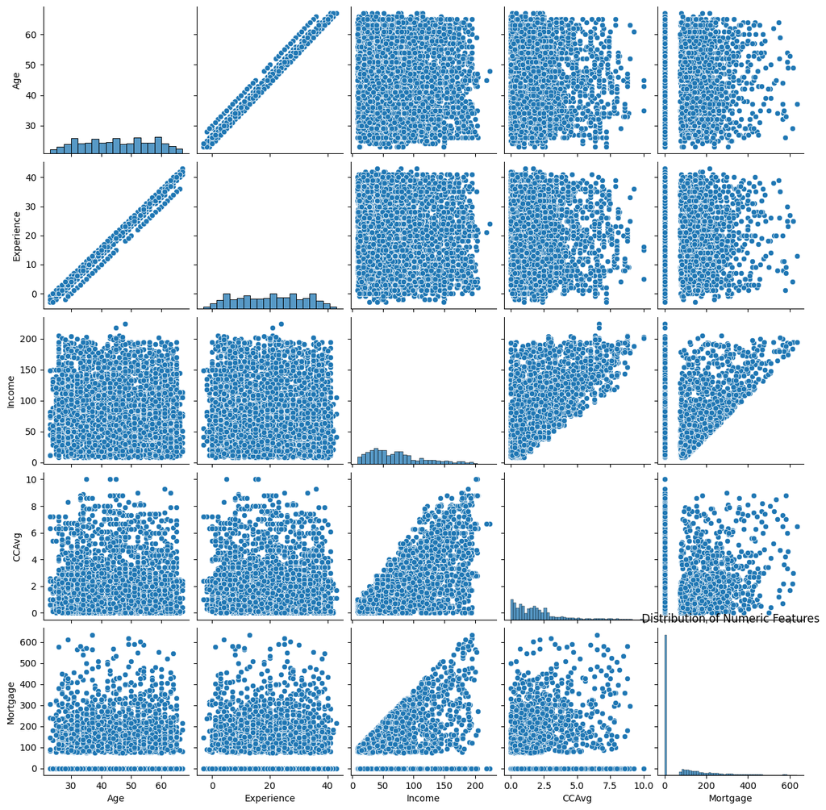

```python
sns.pairplot(df[numeric_features])
plt.title("Distribution of Numeric Features")
plt.show()
```

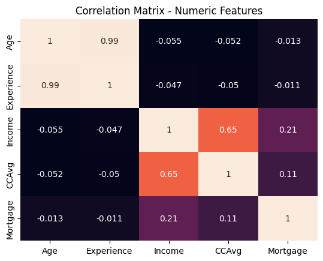

```python
sns.heatmap(df[numeric_features].corr(),cbar=False,annot=True)
plt.title("Correlation Matrix - Numeric Features")
plt.show()
```

## Univariate Analysis

```python
def create_boxplot(data, numeric_features, hue=None):
    columns = 2
    rows = int(np.ceil(len(numeric_features) / columns))

    fig, axes = plt.subplots(rows, columns, figsize=(14, 5 * rows))
    axes = axes.flatten()  # Make it easier to index
    legend_labels = None

    for i, feature in enumerate(numeric_features):
        ax = axes[i]
        plot = sns.boxplot(data=data, x=feature, hue=hue, ax=ax)
        ax.set_title(f"Boxplot for {feature}")

        # Store legend info from first plot only
        if i == 0 and hue:
            handles, labels = ax.get_legend_handles_labels()
            legend_labels = (handles, labels)

        # Remove legend from all but the first subplot
        if hue:
            ax.legend_.remove()

    # Hide any unused subplots
    for j in range(i + 1, len(axes)):
        fig.delaxes(axes[j])

    # Add the legend at the top center
    if legend_labels:
        fig.legend(*legend_labels, loc='upper center', ncol=len(legend_labels[1]), fontsize='medium')

    plt.tight_layout(rect=[0, 0, 1, 0.95])  # leave space at top for legend
    plt.show()
```

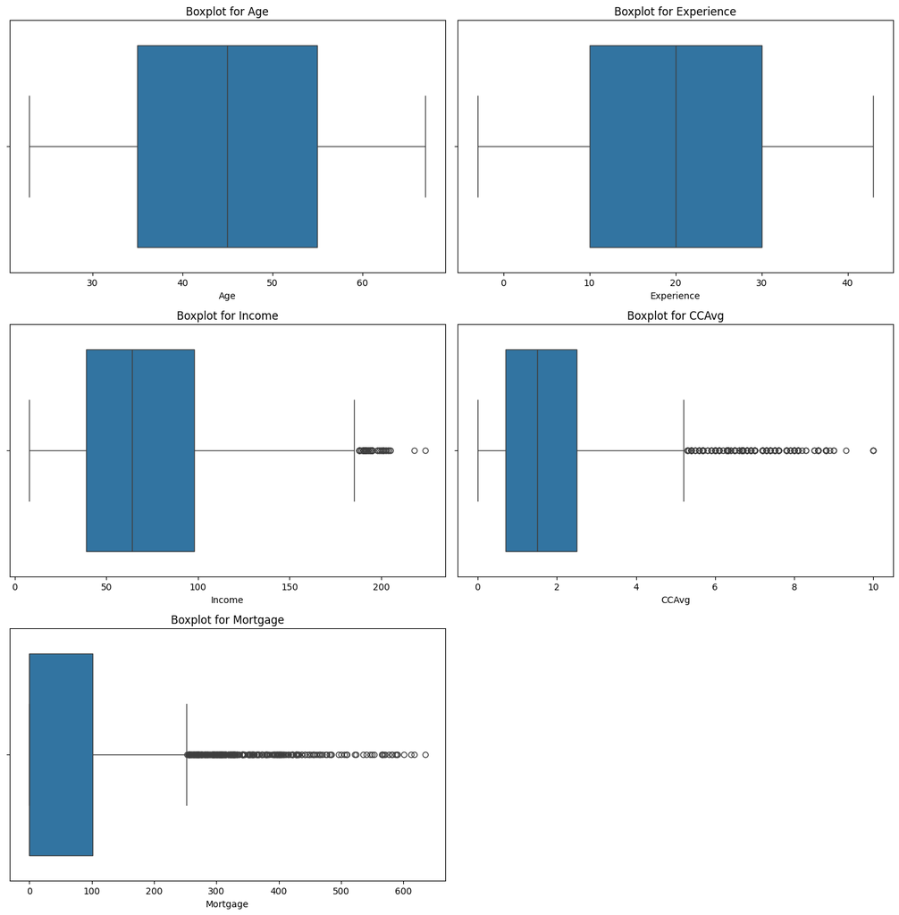

```python
create_boxplot(data=df,numeric_features = numeric_features)
```

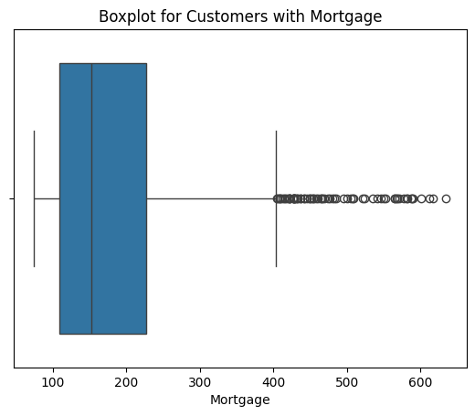

```
 count    1538.000000
mean      183.676203
std       101.361226
min        75.000000
25%       109.000000
50%       153.000000
75%       227.000000
max       635.000000
Name: Mortgage, dtype: float64
```

```python
sns.boxplot(x=df[df.Mortgage > 0].Mortgage)
plt.title("Boxplot for Customers with Mortgage")
plt.show()
print("\n\n",df[df.Mortgage > 0].Mortgage.describe())
```

```python
def create_countplot(data,categorical_features):
    columns = 2
    rows = int(np.ceil(len(categorical_features)/2))

    plt.figure(figsize = (10,7))

    for i,feature in enumerate(categorical_features):
        plt.subplot(rows,columns,i+1)
        sns.countplot(data=data,x=feature)
        plt.title(f"Value Count For {feature}")
        plt.subplots_adjust(wspace=0.2, hspace=1)
```

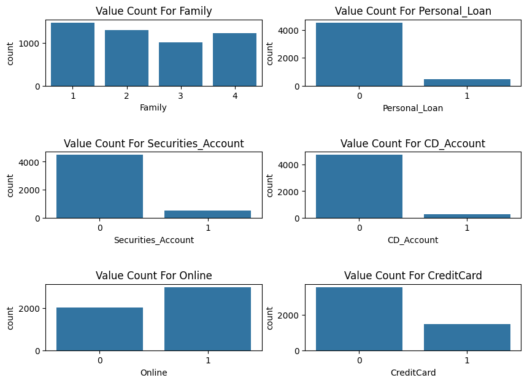

```python
create_countplot(data=df,categorical_features=categorical_binary_features)
```

```python
for i in categorical_binary_features:
    values = df[i].value_counts().reset_index()
    proportion = df[i].value_counts(normalize=1).reset_index()
    proportion["proportion"] = proportion["proportion"] * 100
    value_counts_df = values.merge(proportion,how="inner",on=i).set_index(i)
    print(f"Distinct Value Counts for {i}\n",value_counts_df,"\n")
```

```
Distinct Value Counts for Family
         count  proportion
Family
1        1472       29.44
2        1296       25.92
4        1222       24.44
3        1010       20.20

Distinct Value Counts for Personal_Loan
                count  proportion
Personal_Loan
0               4520        90.4
1                480         9.6

Distinct Value Counts for Securities_Account
                     count  proportion
Securities_Account
0                    4478       89.56
1                     522       10.44

Distinct Value Counts for CD_Account
             count  proportion
CD_Account
0            4698       93.96
1             302        6.04

Distinct Value Counts for Online
         count  proportion
Online
1        2984       59.68
0        2016       40.32

Distinct Value Counts for CreditCard
             count  proportion
CreditCard
0            3530        70.6
1            1470        29.4
```

```python
df.Personal_Loan = df.Personal_Loan.astype(np.object_)
```

### Observations

**For the numerical features:**

**For the categorical features:**

- Almost 70% of customers have 2 or more members (including themselves) in their family
- Around 10% of customers have a securities account
- Only 6% of the customers have a certificate of deposit
- 60% of customers have & use online banking facilities
- 30% of the customers own a credit card
- Dependent Variable: Around 10% (480) customers had previously accepted a personal loan

## Bivariate Analysis

```python
print("Summary Statistics for Numerical Features where Personal Loan = 0\n")
display(df[df.Personal_Loan==0][numeric_features].describe())

print("\nSummary Statistics for Numerical Features where Personal Loan = 1\n")
display(df[df.Personal_Loan==1][numeric_features].describe())
```

```
Summary Statistics for Numerical Features where Personal Loan = 0
```

|  | Age | Experience | Income | CCAvg | Mortgage |
| --- | --- | --- | --- | --- | --- |
| count | 4520.000000 | 4520.000000 | 4520.000000 | 4520.000000 | 4520.000000 |
| mean | 45.367257 | 20.132301 | 66.237389 | 1.729009 | 51.789381 |
| std | 11.450427 | 11.456672 | 40.578534 | 1.567647 | 92.038931 |
| min | 23.000000 | -3.000000 | 8.000000 | 0.000000 | 0.000000 |
| 25% | 35.000000 | 10.000000 | 35.000000 | 0.600000 | 0.000000 |
| 50% | 45.000000 | 20.000000 | 59.000000 | 1.400000 | 0.000000 |
| 75% | 55.000000 | 30.000000 | 84.000000 | 2.300000 | 98.000000 |
| max | 67.000000 | 43.000000 | 224.000000 | 8.800000 | 635.000000 |

```
Summary Statistics for Numerical Features where Personal Loan = 1
```

|  | Age | Experience | Income | CCAvg | Mortgage |
| --- | --- | --- | --- | --- | --- |
| count | 480.000000 | 480.000000 | 480.000000 | 480.000000 | 480.000000 |
| mean | 45.066667 | 19.843750 | 144.745833 | 3.905354 | 100.845833 |
| std | 11.590964 | 11.582443 | 31.584429 | 2.097681 | 160.847862 |
| min | 26.000000 | 0.000000 | 60.000000 | 0.000000 | 0.000000 |
| 25% | 35.000000 | 9.000000 | 122.000000 | 2.600000 | 0.000000 |
| 50% | 45.000000 | 20.000000 | 142.500000 | 3.800000 | 0.000000 |
| 75% | 55.000000 | 30.000000 | 172.000000 | 5.347500 | 192.500000 |
| max | 65.000000 | 41.000000 | 203.000000 | 10.000000 | 617.000000 |

```python
def create_barplot(data, numeric_features, hue=None):
    columns = 2
    rows = int(np.ceil(len(numeric_features) / columns))

    fig, axes = plt.subplots(rows, columns, figsize=(14, 5 * rows))
    axes = axes.flatten()  # Make it easier to index
    legend_labels = None

    for i, feature in enumerate(numeric_features):
        ax = axes[i]
        plot = sns.barplot(data=data, y=feature, hue=hue, ax=ax)
        ax.set_title(f"Avg {feature} By Acceptance Of Personal Loan")

    # Hide any unused subplots
    for j in range(i + 1, len(axes)):
        fig.delaxes(axes[j])

    plt.tight_layout(rect=[0, 0, 1, 0.95])  # leave space at top for legend
    plt.show()
```

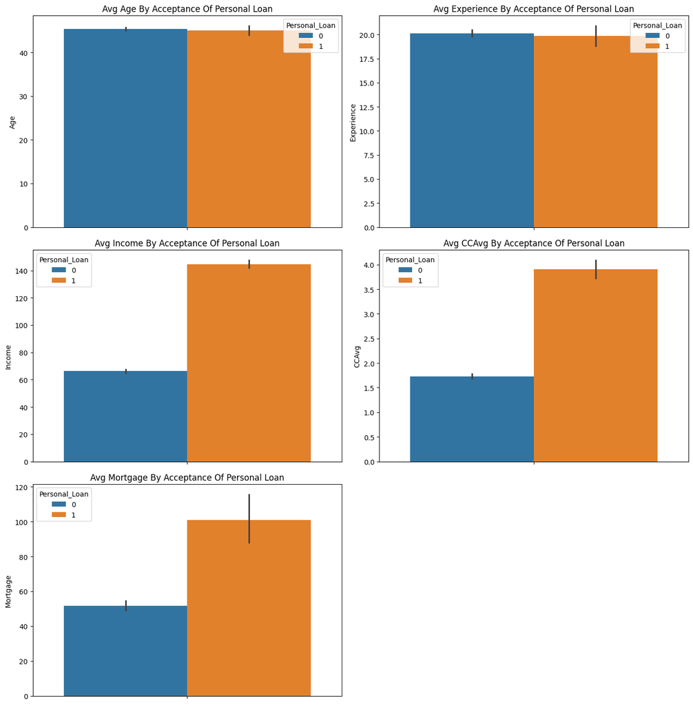

```python
create_barplot(data=df, numeric_features=numeric_features, hue="Personal_Loan")
```

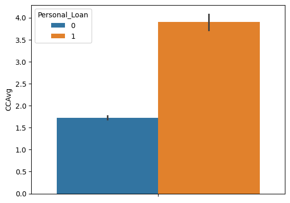

```python
sns.barplot(data=df,y="CCAvg",hue="Personal_Loan")
```

```python
def create_histplot(data, numeric_features, hue=None):
    if not numeric_features:
        print("⚠️ No numeric features provided. Skipping histplot generation.")
        return

    columns = 2
    rows = int(np.ceil(len(numeric_features) / columns))

    fig, axes = plt.subplots(rows, columns, figsize=(14, 5 * rows))
    axes = axes.flatten()
    legend_labels = None

    for i, feature in enumerate(numeric_features):
        ax = axes[i]
        plot = sns.histplot(data=data, x=feature, hue=hue, ax=ax, kde=True)
        ax.set_title(f"Histogram for {feature}")

        # Store legend info from first plot only
        if i == 0 and hue:
            handles, labels = ax.get_legend_handles_labels()
            legend_labels = (handles, labels)

        # Remove legend from other plots safely
        if hue and ax.get_legend() is not None:
            ax.get_legend().remove()

    # Hide any unused subplots
    for j in range(i + 1, len(axes)):
        fig.delaxes(axes[j])

    # Add a shared legend
    if legend_labels and len(legend_labels[0]) > 0:
        fig.legend(*legend_labels, loc='upper center', ncol=len(legend_labels[1]), fontsize='medium')


    plt.tight_layout(rect=[0, 0, 1, 0.95])
    plt.show()
```

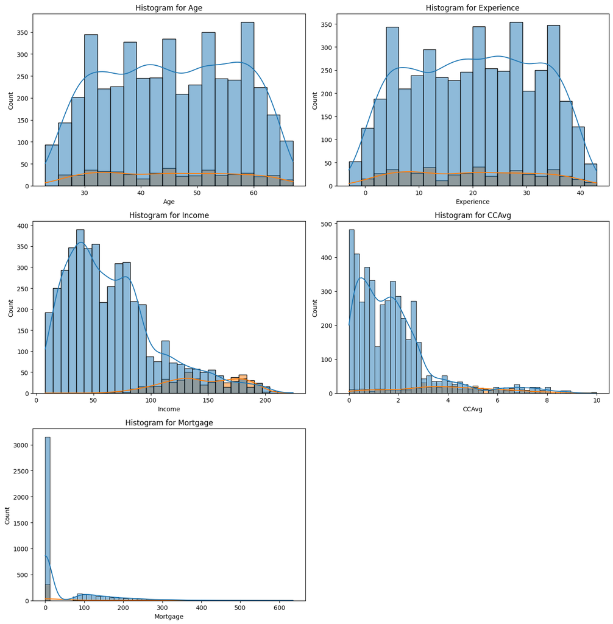

```python
create_histplot(data=df,numeric_features = numeric_features,hue="Personal_Loan")
```

```python
def create_boxplot(data, numeric_features, hue=None):
    columns = 2
    rows = int(np.ceil(len(numeric_features) / columns))

    fig, axes = plt.subplots(rows, columns, figsize=(14, 5 * rows))
    axes = axes.flatten()  # Make it easier to index
    legend_labels = None

    for i, feature in enumerate(numeric_features):
        ax = axes[i]
        plot = sns.boxplot(data=data, x=feature, hue=hue, ax=ax)
        ax.set_title(f"Boxplot for {feature}")

        # Store legend info from first plot only
        if i == 0 and hue:
            handles, labels = ax.get_legend_handles_labels()
            legend_labels = (handles, labels)

        # Remove legend from all but the first subplot
        if hue:
            ax.legend_.remove()

    # Hide any unused subplots
    for j in range(i + 1, len(axes)):
        fig.delaxes(axes[j])

    # Add the legend at the top center
    if legend_labels:
        fig.legend(*legend_labels, loc='upper center', ncol=len(legend_labels[1]), fontsize='medium')

    plt.tight_layout(rect=[0, 0, 1, 0.95])  # leave space at top for legend
    plt.show()
```

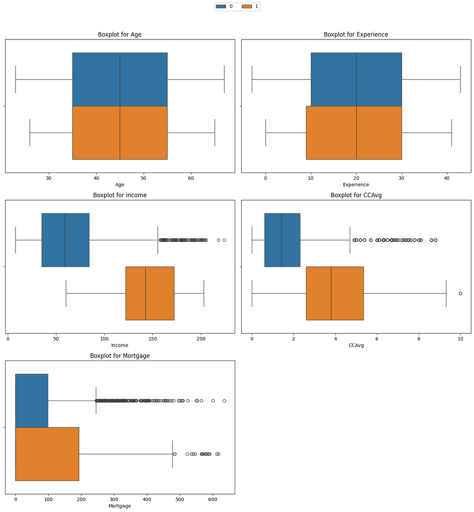

```python
create_boxplot(data=df,numeric_features = numeric_features,hue="Personal_Loan")
```

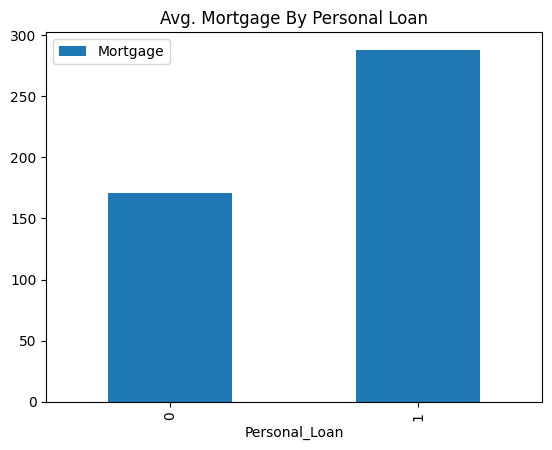

```
                  Mortgage
Personal_Loan
0              170.867153
1              288.130952
```

```python
df[df.Mortgage > 0].groupby("Personal_Loan").agg({"Mortgage":"mean"}).plot(kind="bar")
plt.title("Avg. Mortgage By Personal Loan")
plt.show()
print("\n\n",df[df.Mortgage > 0].groupby("Personal_Loan").agg({"Mortgage":"mean"}))
```

```python
def create_countplots(data, categorical_features, hue=None):
    """
    Creates countplots for each categorical feature, optionally broken down by hue.

    Parameters:
    - data: pandas DataFrame
    - categorical_features: list of column names (categorical variables)
    - hue: column name for hue-based breakdown (optional)
    """
    columns = 2
    rows = int(np.ceil(len(categorical_features) / columns))

    fig, axes = plt.subplots(rows, columns, figsize=(14, 5 * rows))
    axes = axes.flatten()
    legend_labels = None

    for i, feature in enumerate(categorical_features):
        ax = axes[i]
        sns.countplot(data=data, x=feature, hue=hue, ax=ax,stat = 'percent')
        ax.set_title(f"% Total Of {feature}")
        ax.tick_params(axis='x', rotation=45)

        # Save legend from first plot
        if i == 0 and hue:
            handles, labels = ax.get_legend_handles_labels()
            legend_labels = (handles, labels)

        # Remove legend from all but first
        if hue and ax.get_legend() is not None and i != 0:
            ax.get_legend().remove()

    # Hide unused axes
    for j in range(i + 1, len(axes)):
        fig.delaxes(axes[j])

    # Add shared legend
    if hue and legend_labels:
        fig.legend(*legend_labels, loc='upper center', ncol=len(legend_labels[1]), fontsize='medium')

    plt.tight_layout(rect=[0, 0, 1, 0.95])
    plt.show()
```

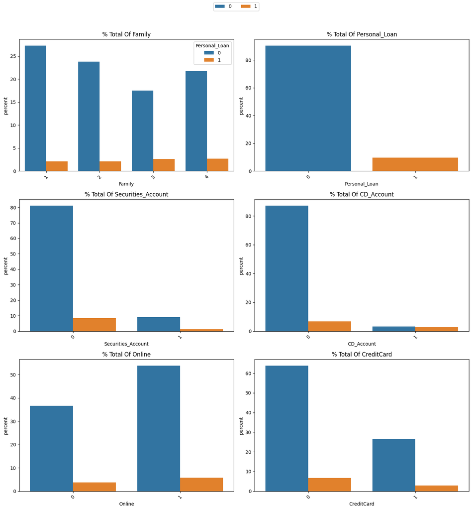

```python
create_countplots(df, categorical_features=categorical_binary_features, hue="Personal_Loan")
```

```python
personal_loan_customers = df[df.Personal_Loan ==1]
no_personal_loan_customers = df[df.Personal_Loan ==0]
```

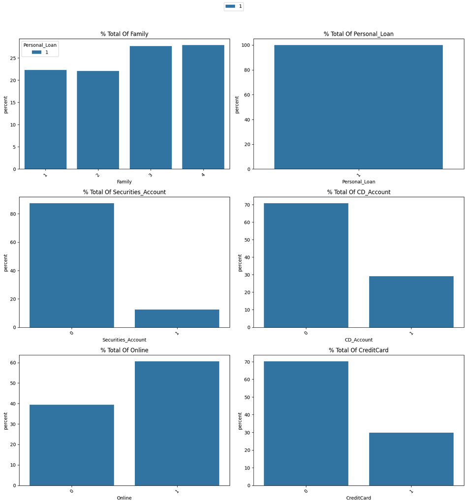

```python
create_countplots(personal_loan_customers, categorical_features=categorical_binary_features, hue="Personal_Loan")
```

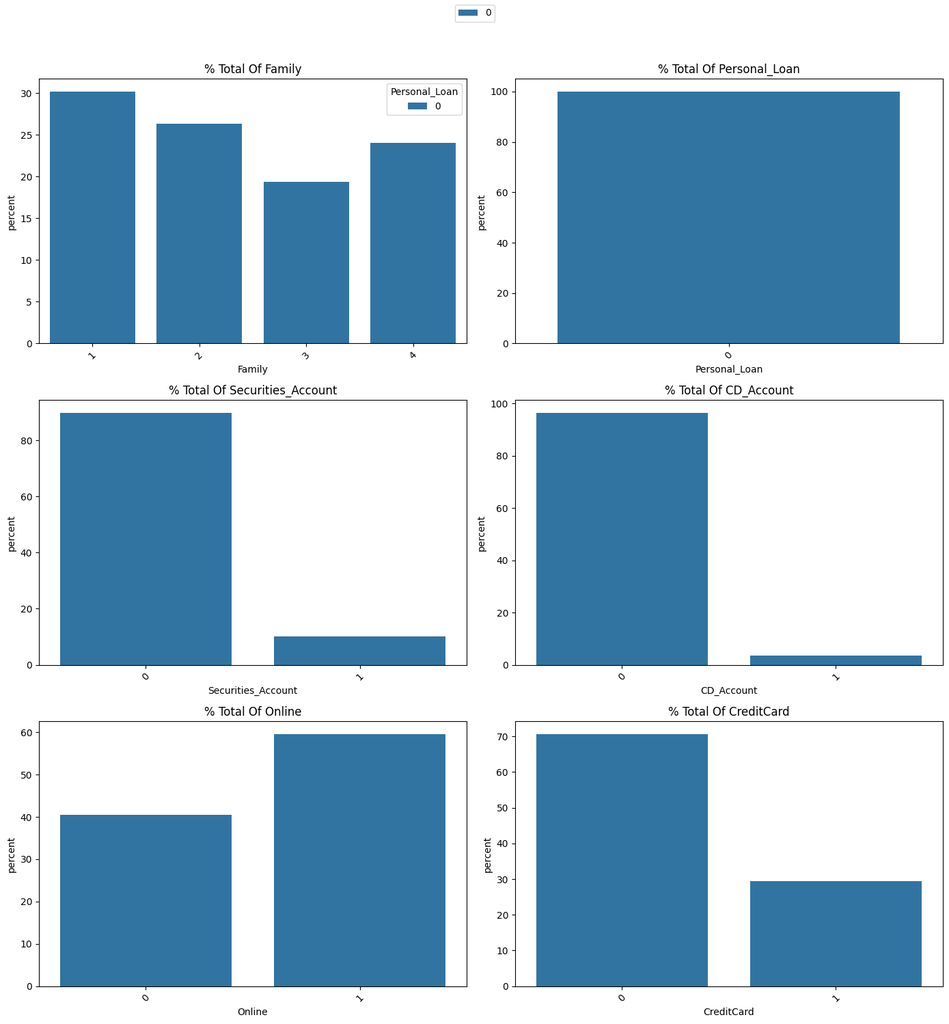

```python
create_countplots(no_personal_loan_customers, categorical_features=categorical_binary_features, hue="Personal_Loan")
```

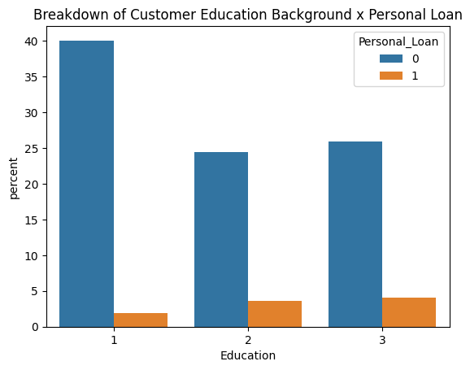

```python
sns.countplot(data=df,x="Education",stat = 'percent',hue="Personal_Loan")
plt.title("Breakdown of Customer Education Background x Personal Loan")
plt.show()
```

### Key Observations

**We'll look into the relationship between the dependent feature Personal_Loan and other independent features to understand the difference in trends or patterns amongst custoemrs who accepted a Personal loan and those who didn't**

- We don't see any difference in age and experience amongst customers who did and who didn't accept personal loan
- **Income**: Customers who accepted a Personal Loan had on average a higher annual income i.e ~142k vs customer didn't i.e ~60K. This implies customers with higher income have a better financial capacity to pay back a loan and might be more attractive prospects for the bank to target.
- **CCAvg**: Customers who accepted a Personal Loan had an average credit card spend tendency i.e 3.8K per month vs those who didn't (1.4K). This could imply that customers who are already leveraging credit actively are more likely to engage with additional lending products like personal loans.
- **Mortgage**: Amongst customers who have taken out a mortgage, customers who accepted a personal loan had an larger amount of mortgage i.e 288K vs customer who didn't accept a loan i.e 170K. This could imply that customers with higher mortgage amounts might find it favourable to accept a personal loan to pay off a mortgage or fend off other expenses
- **Family Members**: Amongst customers who accepted Personal Loan, 55% of customers have 3 or 4 members vs those who didn't (45%). This could imply customers with more family members might be prospective targets for promoting personal loans to, given they have multiple family-related expenses like education, healthcare, or housing.
- **CD Account**: Amongst customers who accepted Personal Loan, 30% had a certificate of deposit. Proportion of customers who didn't accept a personal loan and with a certificate of deposit is lesser than 10%. As the bank looks to turn customers who are currently depositors into borrowers with a personal loans, certificate of deposit holders will make good prospects.
- **Education**: It is observed that % of loan acceptees are higher amongst with customers with higher educational credentials (i.e graduation & professional/advanced). Higher educational attainment may correlate with greater financial literacy, income potential, or willingness to take loans for lifestyle upgrades or professional development — making them attractive segments to target.

## Multi-variate Analysis

```python
import itertools

def create_scatter_matrix(data, numeric_features, hue=None, max_plots=20):
    """
    Creates scatterplots for all pairwise combinations of numeric features,
    optionally colored by a categorical `hue`.

    Parameters:
    - data: pandas DataFrame
    - numeric_features: list of column names that are numeric
    - hue: column name for category breakdown (optional)
    - max_plots: maximum number of plots to show (to avoid too many subplots)
    """
    if len(numeric_features) < 2:
        print("⚠️ At least two numeric features are required for scatterplots.")
        return

    # Get all pairwise combinations
    feature_pairs = list(itertools.combinations(numeric_features, 2))

    # Limit number of plots (optional)
    feature_pairs = feature_pairs[:max_plots]

    cols = 2
    rows = int(np.ceil(len(feature_pairs) / cols))
    fig, axes = plt.subplots(rows, cols, figsize=(7 * cols, 5 * rows))
    axes = axes.flatten()

    for i, (x_feat, y_feat) in enumerate(feature_pairs):
        ax = axes[i]
        sns.scatterplot(data=data, x=x_feat, y=y_feat, hue=hue, ax=ax, alpha=0.7)
        ax.set_title(f"{y_feat} vs {x_feat}")

        # Clean up overlapping legends
        if hue and ax.get_legend() is not None:
            if i != 0:
                ax.get_legend().remove()

    # Hide extra axes if any
    for j in range(i + 1, len(axes)):
        fig.delaxes(axes[j])

    # Shared legend at the top
    if hue:
        handles, labels = axes[0].get_legend_handles_labels()
        if handles and labels:
            fig.legend(handles, labels, loc='upper center', ncol=len(labels), fontsize='medium')

    plt.tight_layout(rect=[0, 0, 1, 0.95])
    plt.show()
```

```python
create_scatter_matrix(data=df,numeric_features=numeric_features,hue="Personal_Loan")
```

```
Output hidden; open in https://colab.research.google.com to view.
```

```python
def create_multivariate_faceted_scatterplots(data, numeric_features, hue, level, columns=2, max_combinations=None):
    """
    Creates scatterplots for each pairwise combination of numeric features,
    faceted by levels of a categorical variable and colored by hue.

    Parameters:
    - data: pandas DataFrame
    - numeric_features: list of numeric column names
    - hue: column name to color points
    - level: column name to facet subplots
    - columns: number of columns per row of subplots
    - max_combinations: optionally limit number of feature pairs
    """
    feature_combinations = list(itertools.combinations(numeric_features, 2))
    if max_combinations:
        feature_combinations = feature_combinations[:max_combinations]

    unique_levels = data[level].dropna().unique()
    n_levels = len(unique_levels)

    for x, y in feature_combinations:
        rows = int(np.ceil(n_levels / columns))
        fig, axes = plt.subplots(rows, columns, figsize=(6.5 * columns, 5 * rows))
        axes = axes.flatten()

        for i, lvl in enumerate(unique_levels):
            ax = axes[i]
            subset = data[data[level] == lvl]

            sns.scatterplot(data=subset, x=x, y=y, hue=hue, ax=ax, alpha=0.7)
            ax.set_title(f"{x} vs {y} | {level} = {lvl}")

            if i != 0 and ax.get_legend():
                ax.get_legend().remove()

        # Remove extra empty subplots
        for j in range(i + 1, len(axes)):
            fig.delaxes(axes[j])

        # Add shared legend
        handles, labels = axes[0].get_legend_handles_labels()
        if handles and labels:
            fig.legend(handles, labels, loc='upper center', ncol=len(labels), fontsize='medium',bbox_to_anchor=(1, 1.05))

        # Add border around the full figure
        fig.subplots_adjust(top=0.90)
        fig.suptitle(f"Feature Pair: {x} vs {y}", fontsize=16, fontweight='bold', color='darkgreen')
        fig.patch.set_edgecolor('black')
        fig.patch.set_linewidth(3)

        plt.tight_layout(rect=[0, 0, 1, 0.93])
        plt.show()
```

```python
create_multivariate_faceted_scatterplots(data=df,numeric_features=numeric_features,hue='Personal_Loan',level='CreditCard')
```

```
Output hidden; open in https://colab.research.google.com to view.
```

```python
create_multivariate_faceted_scatterplots(data=df,numeric_features=numeric_features,hue='Personal_Loan',level='Family')
```

```
Output hidden; open in https://colab.research.google.com to view.
```

### Observations

```python
create_multivariate_faceted_scatterplots(data=df,numeric_features=numeric_features,hue='Personal_Loan',level='Education')
```

```
Output hidden; open in https://colab.research.google.com to view.
```

### Observations

```python
create_multivariate_faceted_scatterplots(data=df,numeric_features=numeric_features,hue='Personal_Loan',level='Online')
```

```
Output hidden; open in https://colab.research.google.com to view.
```

### Observations

```python
create_multivariate_faceted_scatterplots(data=df,numeric_features=numeric_features,hue='Personal_Loan',level='Securities_Account')
```

```
Output hidden; open in https://colab.research.google.com to view.
```

```python
create_multivariate_faceted_scatterplots(data=df,numeric_features=numeric_features,hue='Personal_Loan',level='CD_Account')
```

```
Output hidden; open in https://colab.research.google.com to view.
```

### Key Observations

- Customers who accepted a personal loan tend to exhibit both high annual income and higher average monthly credit card spend.This combination suggests strong purchasing power and financial activity, making them ideal targets for personalized loan offers with premium benefits.
- Also, Customers who have accepted a personal loan tend to have high income but also higher mortgage amounts. These customers may be more open to loan consolidation, refinancing options, or secondary personal loans to manage large existing financial commitments.
- Most of the previous loan acceptors had more than 2 family members AND have higher Annual Income, Credit Spend or Mortgage. This group may have more diverse financial needs (education, healthcare, housing), making them more responsive to campaigns emphasizing family support and financial flexibility.
- Customers with graduate or more advanced educational qualifications along with high annual income, mortgage and monthly credit spend have higher loan acceptance rates. These individuals may be more financially savvy and responsive to professionally packaged loan products positioned as tools for lifestyle or career advancement.
- Certificate of Deposit holders with high income, CC Avg spend and/or mortgage also have a high proportion of personal loan acceptors. This highlights an opportunity for cross-selling personal loans to CD holders as they may already trust the bank for long-term deposits.

## Data Pre-Processing

Prepare the data for analysis: - Missing Value Treatment (if needed) - Outlier Detection (treat, if needed) - Feature Engineering - Data preparation for modelling

### Missing Value Treatment

```python
df.info()
```

```
<class 'pandas.core.frame.DataFrame'>
Index: 5000 entries, 1 to 5000
Data columns (total 13 columns):
 #   Column              Non-Null Count  Dtype
---  ------              --------------  -----
 0   Age                 5000 non-null   int64
 1   Experience          5000 non-null   int64
 2   Income              5000 non-null   int64
 3   ZIPCode             5000 non-null   object
 4   Family              5000 non-null   int64
 5   CCAvg               5000 non-null   float64
 6   Education           5000 non-null   int64
 7   Mortgage            5000 non-null   int64
 8   Personal_Loan       5000 non-null   object
 9   Securities_Account  5000 non-null   int64
 10  CD_Account          5000 non-null   int64
 11  Online              5000 non-null   int64
 12  CreditCard          5000 non-null   int64
dtypes: float64(1), int64(10), object(2)
memory usage: 546.9+ KB
```

```python
df.Experience.describe()
```

|  | Experience |
| --- | --- |
| count | 5000.000000 |
| mean | 20.104600 |
| std | 11.467954 |
| min | -3.000000 |
| 25% | 10.000000 |
| 50% | 20.000000 |
| 75% | 30.000000 |
| max | 43.000000 |

**dtype:** float64

```python
df[df.Experience==-3]
```

| ID | Age | Experience | Income | ZIPCode | Family | CCAvg | Education | Mortgage | Personal_Loan | Securities_Account | CD_Account | Online | CreditCard |
| --- | --- | --- | --- | --- | --- | --- | --- | --- | --- | --- | --- | --- | --- |
| 2619 | 23 | -3 | 55 | 92704 | 3 | 2.4 | 2 | 145 | 0 | 0 | 0 | 1 | 0 |
| 3627 | 24 | -3 | 28 | 90089 | 4 | 1.0 | 3 | 0 | 0 | 0 | 0 | 0 | 0 |
| 4286 | 23 | -3 | 149 | 93555 | 2 | 7.2 | 1 | 0 | 0 | 0 | 0 | 1 | 0 |
| 4515 | 24 | -3 | 41 | 91768 | 4 | 1.0 | 3 | 0 | 0 | 0 | 0 | 1 | 0 |

```python
df.groupby("Age").agg({"Experience":"mean"}).round()
```

| Age | Experience |
| --- | --- |
| 23 | -2.0 |
| 24 | -1.0 |
| 25 | -0.0 |
| 26 | 1.0 |
| 27 | 2.0 |
| 28 | 3.0 |
| 29 | 4.0 |
| 30 | 5.0 |
| 31 | 6.0 |
| 32 | 7.0 |
| 33 | 8.0 |
| 34 | 9.0 |
| 35 | 10.0 |
| 36 | 11.0 |
| 37 | 12.0 |
| 38 | 13.0 |
| 39 | 14.0 |
| 40 | 15.0 |
| 41 | 16.0 |
| 42 | 17.0 |
| 43 | 18.0 |
| 44 | 19.0 |
| 45 | 20.0 |
| 46 | 21.0 |
| 47 | 22.0 |
| 48 | 23.0 |
| 49 | 24.0 |
| 50 | 25.0 |
| 51 | 26.0 |
| 52 | 27.0 |
| 53 | 27.0 |
| 54 | 28.0 |
| 55 | 29.0 |
| 56 | 30.0 |
| 57 | 32.0 |
| 58 | 33.0 |
| 59 | 34.0 |
| 60 | 35.0 |
| 61 | 36.0 |
| 62 | 37.0 |
| 63 | 38.0 |
| 64 | 39.0 |
| 65 | 40.0 |
| 66 | 41.0 |
| 67 | 42.0 |

### Observation -

```python
df.Experience = df.Experience.replace(-3,0)
```

### Outlier Detection

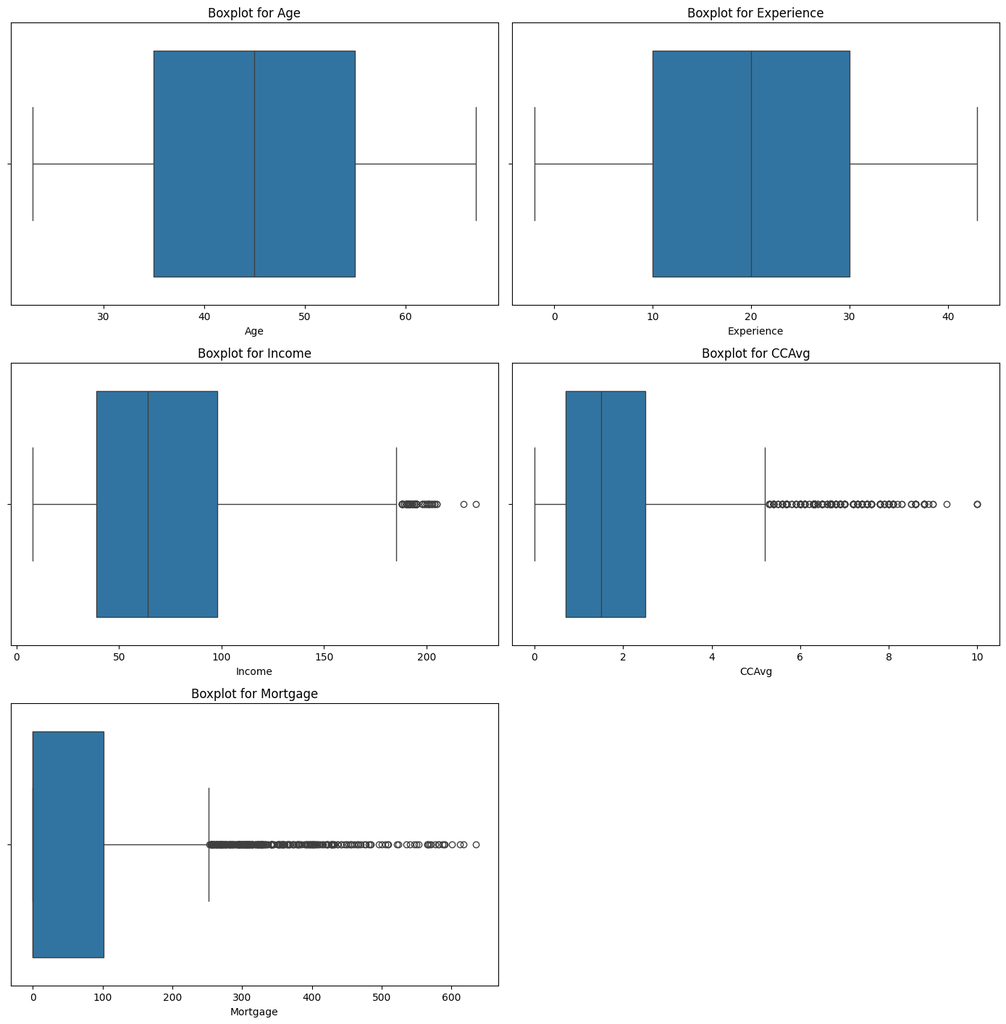

```python
create_boxplot(data=df,numeric_features = numeric_features)
```

### Observations

- Based on our observations in the exploratory data analysis, the features "CCAvg", "Mortgage" and "Income" have many positively skewed outliers.
- Given the strong correlation these features have shown with the dependent feature "Personal_Loan", these outliers could be help to split the leafs
- Hence we'll skip excluding or treating outliers at this stage and revisit based on model performance

```python
#%pip install uszipcode
```

```python
df.drop("ZIPCode",axis=1,inplace=True)
```

## Model Building

```python
df.head()
```

| ID | Age | Experience | Income | Family | CCAvg | Education | Mortgage | Personal_Loan | Securities_Account | CD_Account | Online | CreditCard |
| --- | --- | --- | --- | --- | --- | --- | --- | --- | --- | --- | --- | --- |
| 1 | 25 | 1 | 49 | 4 | 1.6 | 1 | 0 | 0 | 1 | 0 | 0 | 0 |
| 2 | 45 | 19 | 34 | 3 | 1.5 | 1 | 0 | 0 | 1 | 0 | 0 | 0 |
| 3 | 39 | 15 | 11 | 1 | 1.0 | 1 | 0 | 0 | 0 | 0 | 0 | 0 |
| 4 | 35 | 9 | 100 | 1 | 2.7 | 2 | 0 | 0 | 0 | 0 | 0 | 0 |
| 5 | 35 | 8 | 45 | 4 | 1.0 | 2 | 0 | 0 | 0 | 0 | 0 | 1 |

```python
Y = df.Personal_Loan.astype(np.number)
X = df.drop(["Personal_Loan"],axis=1)
```

```python
X_train, X_test, y_train, y_test = train_test_split(X, Y, test_size=0.4, random_state=1)
```

```python
X_train
```

| ID | Age | Experience | Income | Family | CCAvg | Education | Mortgage | Securities_Account | CD_Account | Online | CreditCard |
| --- | --- | --- | --- | --- | --- | --- | --- | --- | --- | --- | --- |
| 4523 | 31 | 5 | 29 | 1 | 0.3 | 1 | 0 | 0 | 0 | 0 | 0 |
| 2852 | 61 | 36 | 81 | 3 | 1.8 | 2 | 0 | 0 | 0 | 1 | 0 |
| 2314 | 58 | 32 | 54 | 3 | 0.3 | 2 | 0 | 0 | 0 | 1 | 1 |
| 983 | 58 | 33 | 52 | 3 | 0.5 | 2 | 0 | 0 | 0 | 0 | 1 |
| 1165 | 41 | 17 | 94 | 3 | 3.8 | 2 | 327 | 1 | 1 | 1 | 0 |
| ... | ... | ... | ... | ... | ... | ... | ... | ... | ... | ... | ... |
| 2896 | 60 | 36 | 39 | 4 | 1.3 | 2 | 140 | 0 | 0 | 1 | 0 |
| 2764 | 55 | 31 | 13 | 4 | 0.7 | 1 | 0 | 0 | 0 | 1 | 0 |
| 906 | 46 | 22 | 28 | 1 | 1.0 | 1 | 84 | 0 | 0 | 1 | 1 |
| 3981 | 46 | 22 | 89 | 4 | 1.4 | 2 | 0 | 0 | 0 | 1 | 0 |
| 236 | 38 | 8 | 71 | 4 | 1.8 | 3 | 0 | 0 | 0 | 1 | 0 |

3000 rows × 11 columns

```python
y_train.value_counts(normalize=True)
```

| Personal_Loan | proportion |
| --- | --- |
| 0.0 | 0.904333 |
| 1.0 | 0.095667 |

**dtype:** float64

```python
y_test.value_counts(normalize=True)
```

| Personal_Loan | proportion |
| --- | --- |
| 0.0 | 0.9035 |
| 1.0 | 0.0965 |

**dtype:** float64

```python
def evaluate_classification_model(name, model, X_train, y_train, X_test, y_test, cv=5):
    """
    Evaluates a classification model on cross-validation and test set.
    Returns results as a dictionary (ready to be appended to a DataFrame).

    Parameters:
        name (str): Name of the model
        model (sklearn estimator): The model to train and evaluate
        X_train, y_train: Training data
        X_test, y_test: Test data
        cv (int): Number of CV folds

    Returns:
        dict: Model name + CV and test scores for multiple metrics
    """
    # Cross-validation setup
    skf = StratifiedKFold(n_splits=cv, shuffle=True, random_state=42)
    cv_preds = cross_val_predict(model, X_train, y_train, cv=skf, method='predict')
    model.fit(X_train, y_train)
    test_preds = model.predict(X_test)

    # CV metrics
    cv_acc = accuracy_score(y_train, cv_preds)
    cv_prec = precision_score(y_train, cv_preds, zero_division=0)
    cv_rec = recall_score(y_train, cv_preds, zero_division=0)
    cv_f1 = f1_score(y_train, cv_preds, zero_division=0)

    # Test metrics
    test_acc = accuracy_score(y_test, test_preds)
    test_prec = precision_score(y_test, test_preds, zero_division=0)
    test_rec = recall_score(y_test, test_preds, zero_division=0)
    test_f1 = f1_score(y_test, test_preds, zero_division=0)

    return {
        'Model': name,
        'CV_Accuracy': round(cv_acc, 4),
        'CV_Precision': round(cv_prec, 4),
        'CV_Recall': round(cv_rec, 4),
        'CV_F1': round(cv_f1, 4),
        'Test_Accuracy': round(test_acc, 4),
        'Test_Precision': round(test_prec, 4),
        'Test_Recall': round(test_rec, 4),
        'Test_F1': round(test_f1, 4),
    }
```

```python
def plot_confusion_matrix(y_true, y_pred, labels=None, title="Confusion Matrix", cmap="Blues"):
    """
    Plots a confusion matrix with labeled axes.

    Parameters:
        y_true (array-like): Actual labels
        y_pred (array-like): Predicted labels
        labels (list): Optional list of label names (e.g., ['No', 'Yes'])
        title (str): Title of the plot
        cmap (str): Color map for heatmap
    """
    cm = confusion_matrix(y_true, y_pred)
    plt.figure(figsize=(6, 5))
    sns.heatmap(cm, annot=True, fmt='d', cmap=cmap, xticklabels=labels, yticklabels=labels)
    plt.title(title, fontsize=14, pad=10)
    plt.xlabel("Predicted", fontsize=12)
    plt.ylabel("Actual", fontsize=12)
    plt.tight_layout()
    plt.show()
```

```python
def print_classification_report(y_true, y_pred, target_names=None):
    """
    Prints a classification report with precision, recall, f1-score, and support.

    Parameters:
        y_true (array-like): True labels
        y_pred (array-like): Predicted labels
        target_names (list): Optional class label names (e.g., ['Not Campaign', 'Campaign'])
    """
    report = classification_report(y_true, y_pred, target_names=target_names, zero_division=0)
    print("📋 Classification Report:\n")
    print(report)
```

```python
def plot_feature_importance(model, feature_names, top_n=None, title="Feature Importances", figsize=(10, 6), color="skyblue"):
    """
    Plots feature importances for tree-based models.

    Parameters:
        model: Trained model with `feature_importances_` attribute
        feature_names (list): List of feature names
        top_n (int): Number of top features to display (default: all)
        title (str): Title of the plot
        figsize (tuple): Size of the figure
        color (str): Bar color
    """
    importances = model.feature_importances_
    feature_df = pd.DataFrame({
        'Feature': feature_names,
        'Importance': importances
    }).sort_values(by='Importance', ascending=False)

    if top_n:
        feature_df = feature_df.head(top_n)

    plt.figure(figsize=figsize)
    sns.barplot(x='Importance', y='Feature', data=feature_df, color=color)
    plt.title(title, fontsize=14, pad=10)
    plt.xlabel("Importance Score", fontsize=12)
    plt.ylabel("Feature", fontsize=12)
    plt.tight_layout()
    plt.show()
```

```python
from sklearn.tree import export_graphviz
import graphviz

def render_tree_graphviz(model, feature_names, class_names=None):
    """
    Renders a decision tree using Graphviz directly inside a Jupyter Notebook.

    Parameters:
        model: Trained DecisionTreeClassifier or DecisionTreeRegressor
        feature_names (list): Names of the input features
        class_names (list): Optional list of class names for classification
    """
    dot_data = export_graphviz(
        model,
        out_file=None,
        feature_names=feature_names,
        class_names=class_names,
        filled=True,
        rounded=True,
        special_characters=True
    )
    return graphviz.Source(dot_data)
```

```python
results = []
results_df = pd.DataFrame()
```

```python
baseline_model = DecisionTreeClassifier(random_state=42)

results.append(evaluate_classification_model("Baseline Decision Tree", baseline_model, X_train, y_train, X_test, y_test))

results_df = pd.concat([results_df,pd.DataFrame(results)],ignore_index=True)
```

```python
baseline_model.fit(X_train,y_train)
y_pred = baseline_model.predict(X_test)
```

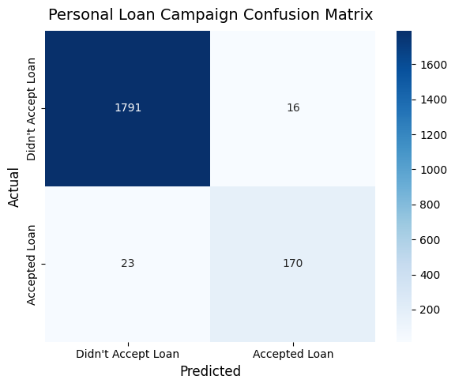

```
📋 Classification Report:

                    precision    recall  f1-score   support

Didn't Accept Loan       0.99      0.99      0.99      1807
     Accepted Loan       0.91      0.88      0.90       193

          accuracy                           0.98      2000
         macro avg       0.95      0.94      0.94      2000
      weighted avg       0.98      0.98      0.98      2000
```

```python
# Confusion Matrix
plot_confusion_matrix(y_test, y_pred, labels=["Didn't Accept Loan", "Accepted Loan"], title="Personal Loan Campaign Confusion Matrix")

# Classification Report
print_classification_report(y_test, y_pred, target_names=["Didn't Accept Loan", "Accepted Loan"])
```

```python
results_df
```

|  | Model | CV_Accuracy | CV_Precision | CV_Recall | CV_F1 | Test_Accuracy | Test_Precision | Test_Recall | Test_F1 |
| --- | --- | --- | --- | --- | --- | --- | --- | --- | --- |
| 0 | Baseline Decision Tree | 0.9823 | 0.898 | 0.9199 | 0.9088 | 0.9805 | 0.914 | 0.8808 | 0.8971 |

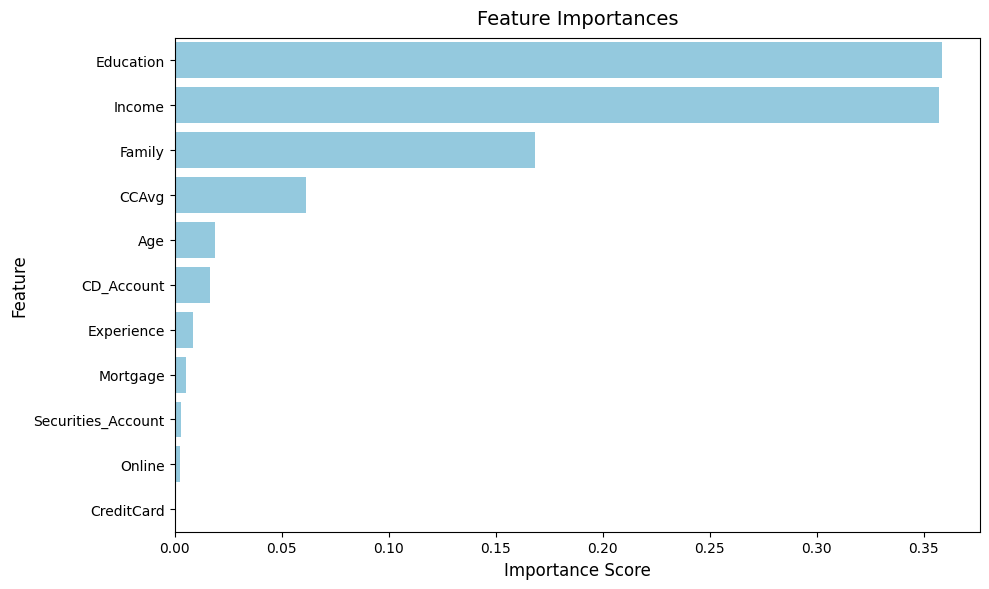

```python
plot_feature_importance(baseline_model, feature_names=X_train.columns)
```

```python
tree_graph = render_tree_graphviz(model=baseline_model,feature_names=X_train.columns,class_names=["Didn't Accept Loan", "Accepted Loan"])
tree_graph  # This renders the tree inline in your notebook
```

[figure not shown]

### Key Observations For Baseline Model

- For the basis of model evaluation, we'll be using Recall as the primary metric of evaluation
- Recall essentially will help us identify how many of the potential liability customers who would possibly accept a loan we can reach out to.
- Due to higher value/emphasis on increase customer base & revenue, we need to ensure we don't miss out on probable customers
- The baseline model has a recall score of ~92% on the cross validation training sets while having a 88% recall on the unseen test set (170 of the 193) when predicting personal loan accepting customers.
- The model is showing good generalisation capabilities.
- However, we can try pruning techniques to try and optimise the decision tree, increase generalisation and performance
- Based on the model's feature importance scores, Income & Education are the 2 most important factors for identfying personal loan customers. Other features that played important roles in prediction of loan accepting customers - Family Members, CC Avg & Age

## Decision Tree Pruning

### Pre-Pruning

```python
param_grid = {
    'max_depth': [3, 5, 7, 10, 12, 15, 20],  # Wider range including deeper trees
    'min_samples_split': [2, 5, 10, 20, 40, 60],   # More thresholds to test for splitting
    'min_samples_leaf': [1, 2, 5, 10, 20, 40],     # Helps avoid tiny or noisy leaves
    'max_leaf_nodes': [10, 20, 30, 50, 75, 100]  # Control final model complexity
}
```

```python
# Define preferred scoring metric (e.g., 'f1', 'accuracy', 'roc_auc')
scoring = 'recall'

# Setup cross-validation strategy
cv_strategy = StratifiedKFold(n_splits=5, shuffle=True, random_state=42)

# GridSearchCV
pre_prunning_grid_search = GridSearchCV(
    estimator=baseline_model,
    param_grid=param_grid,
    cv=cv_strategy,
    scoring=scoring,
    n_jobs=-1,  # Use all cores
    verbose=1
)
```

```python
# Fit to training data
pre_prunning_grid_search.fit(X_train, y_train)

# Best model + params
pre_prunning_best_model = pre_prunning_grid_search.best_estimator_
print("Best Parameters:\n", pre_prunning_grid_search.best_params_)
print(f"Best {scoring} score (CV avg): {pre_prunning_grid_search.best_score_:.4f}")
```

```
Fitting 5 folds for each of 1512 candidates, totalling 7560 fits
Best Parameters:
 {'max_depth': 5, 'max_leaf_nodes': 10, 'min_samples_leaf': 1, 'min_samples_split': 2}
Best recall score (CV avg): 0.9235
```

```python
prepruned_model = DecisionTreeClassifier(random_state=42,max_depth= 5, max_leaf_nodes=10, min_samples_leaf= 1, min_samples_split= 2)

results.append(evaluate_classification_model("Pre Pruned Decision Tree", prepruned_model, X_train, y_train, X_test, y_test))

results_df = pd.concat([results_df,pd.DataFrame(results)],ignore_index=True)
```

```python
results_df
```

|  | Model | CV_Accuracy | CV_Precision | CV_Recall | CV_F1 | Test_Accuracy | Test_Precision | Test_Recall | Test_F1 |
| --- | --- | --- | --- | --- | --- | --- | --- | --- | --- |
| 0 | Baseline Decision Tree | 0.9823 | 0.8980 | 0.9199 | 0.9088 | 0.9805 | 0.9140 | 0.8808 | 0.8971 |
| 1 | Baseline Decision Tree | 0.9823 | 0.8980 | 0.9199 | 0.9088 | 0.9805 | 0.9140 | 0.8808 | 0.8971 |
| 2 | Pre Pruned Decision Tree | 0.9870 | 0.9397 | 0.9233 | 0.9315 | 0.9825 | 0.9247 | 0.8912 | 0.9077 |

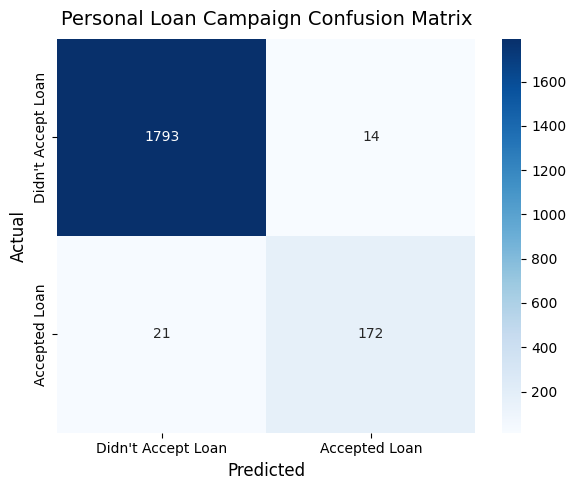

```
📋 Classification Report:

                    precision    recall  f1-score   support

Didn't Accept Loan       0.99      0.99      0.99      1807
     Accepted Loan       0.92      0.89      0.91       193

          accuracy                           0.98      2000
         macro avg       0.96      0.94      0.95      2000
      weighted avg       0.98      0.98      0.98      2000
```

```python
prepruned_model_y_pred = prepruned_model.predict(X_test)

# Confusion Matrix
plot_confusion_matrix(y_test, prepruned_model_y_pred, labels=["Didn't Accept Loan", "Accepted Loan"], title="Personal Loan Campaign Confusion Matrix")

# Classification Report
print_classification_report(y_test, prepruned_model_y_pred, target_names=["Didn't Accept Loan", "Accepted Loan"])
```

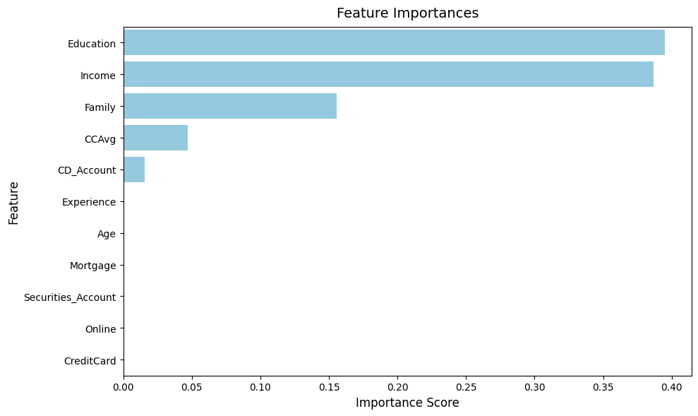

```python
plot_feature_importance(prepruned_model, feature_names=X_train.columns)
```

```python
prepruned_model_tree_graph = render_tree_graphviz(model=prepruned_model,feature_names=X_train.columns,class_names=["Didn't Accept Loan", "Accepted Loan"])
prepruned_model_tree_graph  # This renders the tree inline in your notebook
```

[figure not shown]

### Key Observations

```python
post_pruning_param_grid = {
    'ccp_alpha': [0.0001, 0.001, 0.005, 0.01, 0.02, 0.05, 0.1]
}
```

```python
new_baseline_model = DecisionTreeClassifier(random_state=42)

# GridSearchCV
post_prunning_grid_search = GridSearchCV(
    estimator=new_baseline_model,
    param_grid=post_pruning_param_grid,
    cv=cv_strategy,
    scoring=scoring,
    n_jobs=-1,  # Use all cores
    verbose=1
)
```

```python
# Fit to training data
post_prunning_grid_search.fit(X_train, y_train)

# Best model + params
post_prunning_best_model = post_prunning_grid_search.best_estimator_
print("Best Parameters:\n", post_prunning_grid_search.best_params_)
print(f"Best {scoring} score (CV avg): {post_prunning_grid_search.best_score_:.4f}")
```

```
Fitting 5 folds for each of 7 candidates, totalling 35 fits
Best Parameters:
 {'ccp_alpha': 0.0001}
Best recall score (CV avg): 0.9200
```

```python
postpruned_model = DecisionTreeClassifier(random_state=42,ccp_alpha=0.0001)

results.append(evaluate_classification_model("Post Pruned Decision Tree", postpruned_model, X_train, y_train, X_test, y_test))

results_df = pd.concat([results_df,pd.DataFrame(results)],ignore_index=True)
```

```python
results_df
```

|  | Model | CV_Accuracy | CV_Precision | CV_Recall | CV_F1 | Test_Accuracy | Test_Precision | Test_Recall | Test_F1 |
| --- | --- | --- | --- | --- | --- | --- | --- | --- | --- |
| 0 | Baseline Decision Tree | 0.9823 | 0.8980 | 0.9199 | 0.9088 | 0.9805 | 0.9140 | 0.8808 | 0.8971 |
| 1 | Baseline Decision Tree | 0.9823 | 0.8980 | 0.9199 | 0.9088 | 0.9805 | 0.9140 | 0.8808 | 0.8971 |
| 2 | Pre Pruned Decision Tree | 0.9870 | 0.9397 | 0.9233 | 0.9315 | 0.9825 | 0.9247 | 0.8912 | 0.9077 |
| 3 | Baseline Decision Tree | 0.9823 | 0.8980 | 0.9199 | 0.9088 | 0.9805 | 0.9140 | 0.8808 | 0.8971 |
| 4 | Pre Pruned Decision Tree | 0.9870 | 0.9397 | 0.9233 | 0.9315 | 0.9825 | 0.9247 | 0.8912 | 0.9077 |
| 5 | Post Pruned Decision Tree | 0.9823 | 0.8980 | 0.9199 | 0.9088 | 0.9805 | 0.9140 | 0.8808 | 0.8971 |

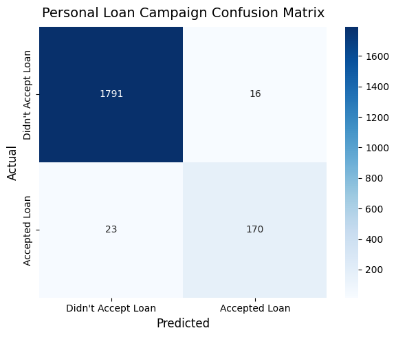

```
📋 Classification Report:

                    precision    recall  f1-score   support

Didn't Accept Loan       0.99      0.99      0.99      1807
     Accepted Loan       0.91      0.88      0.90       193

          accuracy                           0.98      2000
         macro avg       0.95      0.94      0.94      2000
      weighted avg       0.98      0.98      0.98      2000
```

```python
postpruned_model_y_pred = postpruned_model.predict(X_test)

# Confusion Matrix
plot_confusion_matrix(y_test, postpruned_model_y_pred, labels=["Didn't Accept Loan", "Accepted Loan"], title="Personal Loan Campaign Confusion Matrix")

# Classification Report
print_classification_report(y_test, postpruned_model_y_pred, target_names=["Didn't Accept Loan", "Accepted Loan"])
```

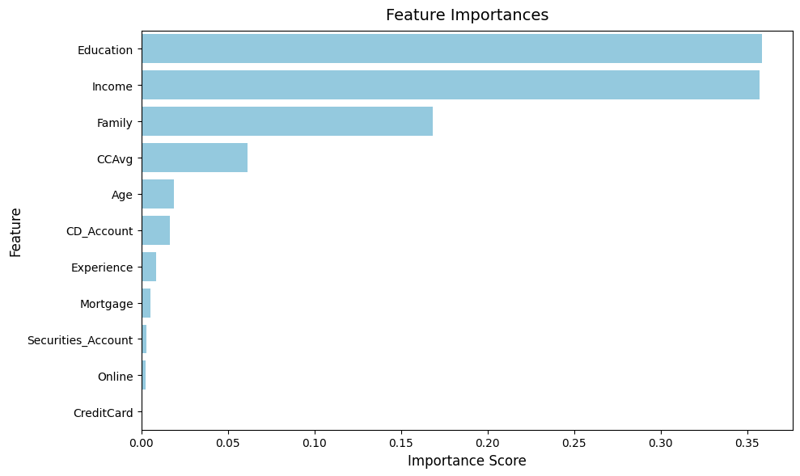

```python
plot_feature_importance(postpruned_model, feature_names=X_train.columns)
```

```python
postpruned_model_tree_graph = render_tree_graphviz(model=postpruned_model,feature_names=X_train.columns,class_names=["Didn't Accept Loan", "Accepted Loan"])
postpruned_model_tree_graph  # This renders the tree inline in your notebook
```

[figure not shown]

### Key Observations

**FINAL VERDICT** - We should propose using the **pre-puned Decision Tree solution** to help the bank identify customers who could accept personal loans

## Actionable Insights & Recommendation For AllLife Bank

1) **Target High-Income Customers**: Customers with higher annual income are significantly more likely to accept personal loans. AllLife Bank can prioritize marketing efforts toward high-income segments with tailored messaging that emphasizes premium benefits and flexible repayment options.

2) **Engage Customers with High Credit Card Spending**: Credit card spending is a strong indicator of loan acceptance. AllLife Bank should identify high-spending credit card users and send them personalized loan offers aligned with their spending habits, such as travel, luxury, or lifestyle purchases.

3) **Focus on Highly Educated Customers**: Customers with graduate or professional degrees show higher conversion rates. AllLife Bank can craft campaigns that position personal loans as enablers for career growth, skill upgrades, or professional investments — especially relevant to educated audiences.

4) **Leverage Larger Family Size**: Larger families are more inclined to take loans, likely due to broader financial needs. The Bank should highlight how personal loans can support family expenses like education, healthcare, or housing (they should make the message family-centric)

5) **Cross-Sell to Existing Account Holders**: Customers with existing deposit or securities accounts are more likely to take personal loans. AllLife Bank can consider cross-selling campaigns to offer bundled products, convenience, and loyalty benefits to customers already banking with them.